# Regression Project.Rmd

Harold Trammel

September 7, 2015

## *Motor Trend* Car Road Tests

### Executive Summary

An analysis of the impact that transmission type has on gas mileage was performed on the *Motor Trend* car data. This data shows that automatic transmissions have negative impact on gasoline mileage when compared to manual transmissions. On average, cars in this data with automatic transmissions have 7.2449 fewer miles per gallon. This is a simplistic conclusion however as there were other variables such as car weight, horsepower, and engine displacement impacting this data. It is recommended that a decision to select a higher mileage car not be made simply on the transmission type.

### Introduction

*Motor Trend* is interested in exploring the relationship between a set of variables and miles per gallon (MPG) (outcome). They have provided a set of data from automobiles that they tested over a period of time. They are particularly interested in the following two questions:

- “Is an automatic or manual transmission better for MPG”
- “Quantify the MPG difference between automatic and manual transmissions”

A modern automobile is a complex machine and as such no one component is fully responsible for its performance and efficiency. Some of the cars in the sample have been designed for performance while others were designed for performance or luxury. This inherent complexity must be kept in mind when looking a single component such as the type of transmission.

### General Exploration

The data that *Motor Trend* provided was eleven different measured collected from 32 different automobiles. Three of the variables (Miles Per Gallon, Gross Horsepower, and 1/4 Mile Time) are dependent on different sets of the other variables. Some of the variables are factors even though their values are numeric. These are: Number of Cylinders, Vee vs Straight Cylinder Arrangement, Transmission Type, Number of Forward Gears, and Number of Carburetors. Displacement, Rear Axle Ratio, and Weight are continuous variables.

As part of the exploration phase, I generated correlation matrix, which is provided in Table 1. Analysis of this matrix identified Number of Cylinders, Gross Horsepower, Displacement, and Weight as having a negative correlation greater than 0.75. Rear Axle Ratio, Vee vs Straight Cylinder Arrangement, Transmission Type, and Number of Forward Gears had mild positive correlation with values between 0.48 and 0.68.

### Focused Analysis

I compared the statistics related to mileage recorded in cars with automatic transmissions to those with manual transmissions (see Table 2). The mean mileage in automatic cars was 17.1474 ± 0.8796 (std. error of mean) with a standard deviation of 3.834. For manual transmission cars, the mean milage 24.3923 ± 1.7103 (std. error of mean) with a standard deviation of 6.1665.

Since there are only two types of transmission, a linear relationship with mileage was obvious. I used a simple linear regression model to confirm my expectation and the resulting coefficients are shown in Table 3. The p-values were less that 0.05 but the variance seen in the basic statistics suggested more analysis was required. I prepared a plot of the residuals of this model (shown in Figure 1). This shows that the manual transmission has approximately a 20 mpg spread. I also prepared a residual QQ plot for this simple linear regression model and the residuals fell very close to the line. Based on this collection of results, it would seem that transmission type is a reasonable predictor of mileage; however, basic knowledge of automobile function warrants additional study.

### Conclusion

Automatic transmissions have been maligned for causing lower gasoline mileage and this analysis supports that assertion. While transmission type plays a role in mileage, other factors are also involved.

### Appendix

Table 1 Correlation Matrix for All Variables

|  | mpg | cyl | disp | hp | drat | wt | qsec | vs | am | gear | carb |
| --- | --- | --- | --- | --- | --- | --- | --- | --- | --- | --- | --- |
| mpg | 1.0000 | -0.8522 | -0.8476 | -0.7762 | 0.6812 | -0.8677 | 0.4187 | 0.6640 | 0.5998 | 0.4803 | -0.5509 |
| cyl | -0.8522 | 1.0000 | 0.9020 | 0.8324 | -0.6999 | 0.7825 | -0.5912 | -0.8108 | -0.5226 | -0.4927 | 0.5270 |
| disp | -0.8476 | 0.9020 | 1.0000 | 0.7909 | -0.7102 | 0.8880 | -0.4337 | -0.7104 | -0.5912 | -0.5556 | 0.3950 |
| hp | -0.7762 | 0.8324 | 0.7909 | 1.0000 | -0.4488 | 0.6587 | -0.7082 | -0.7231 | -0.2432 | -0.1257 | 0.7498 |
| drat | 0.6812 | -0.6999 | -0.7102 | -0.4488 | 1.0000 | -0.7124 | 0.0912 | 0.4403 | 0.7127 | 0.6996 | -0.0908 |
| wt | -0.8677 | 0.7825 | 0.8880 | 0.6587 | -0.7124 | 1.0000 | -0.1747 | -0.5549 | -0.6925 | -0.5833 | 0.4276 |
| qsec | 0.4187 | -0.5912 | -0.4337 | -0.7082 | 0.0912 | -0.1747 | 1.0000 | 0.7445 | -0.2299 | -0.2127 | -0.6562 |
| vs | 0.6640 | -0.8108 | -0.7104 | -0.7231 | 0.4403 | -0.5549 | 0.7445 | 1.0000 | 0.1683 | 0.2060 | -0.5696 |
| am | 0.5998 | -0.5226 | -0.5912 | -0.2432 | 0.7127 | -0.6925 | -0.2299 | 0.1683 | 1.0000 | 0.7941 | 0.0575 |
| gear | 0.4803 | -0.4927 | -0.5556 | -0.1257 | 0.6996 | -0.5833 | -0.2127 | 0.2060 | 0.7941 | 1.0000 | 0.2741 |
| carb | -0.5509 | 0.5270 | 0.3950 | 0.7498 | -0.0908 | 0.4276 | -0.6562 | -0.5696 | 0.0575 | 0.2741 | 1.0000 |

Table 2 Mileage Impact by Transmission Type

| Statistic | Automatic | Manual |
| --- | --- | --- |
| number of values (nbr.val) | 19.0000 | 13.0000 |
| number of null values (nbr.null) | 0.0000 | 0.0000 |
| number of missing values (nbr.na) | 0.0000 | 0.0000 |
| minimal value (min) | 10.4000 | 15.0000 |
| maximal value (max) | 24.4000 | 33.9000 |
| range (range that is max-min) | 14.0000 | 18.9000 |
| sum of all non-missing values (sum) | 325.8000 | 317.1000 |
| median (median) | 17.3000 | 22.8000 |
| mean (mean) | 17.1474 | 24.3923 |
| standard error on mean (SE.mean) | 0.8796 | 1.7103 |
| confidence interval of mean (CI.mean) | 1.8479 | 3.7264 |
| variance (var) | 14.6993 | 38.0258 |
| standard deviation (std.dev) | 3.8340 | 6.1665 |
| variation coefficient (coef.var) | 0.2236 | 0.2528 |

Table 3 Automatic vs Manual Coefficients

|  | Estimate | Std. Error | t value | Pr(>\|t\|) |
| --- | --- | --- | --- | --- |
| (Intercept) | 17.147 | 1.125 | 15.248 | 0.0000 |
| amManual | 7.245 | 1.764 | 4.106 | 0.0003 |

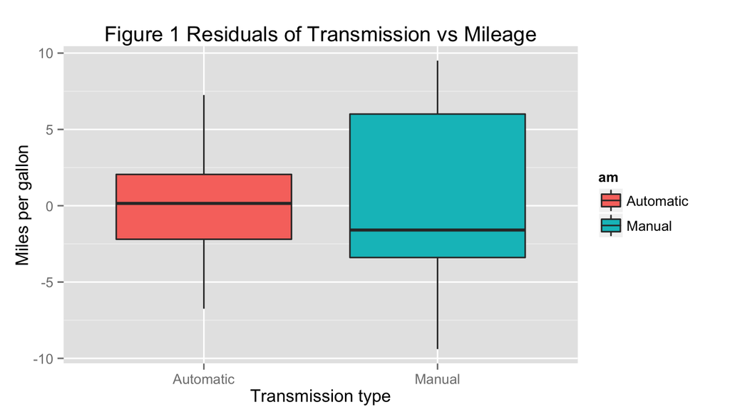

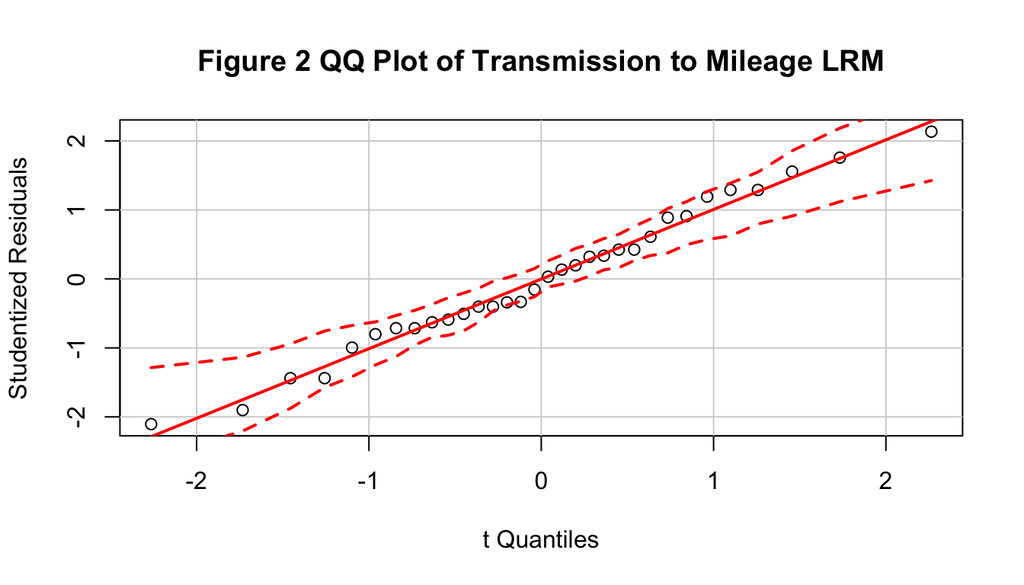

##### Table 4: ANOVA Table of Nested Models

**NOTE:** The results produced by ANOVA in knitr are different from the results in R environment and in RStudio.

```
## Analysis of Variance Table
##
## Model 1: mpg ~ am
## Model 2: mpg ~ am + wt
## Model 3: mpg ~ am + wt + carb
## Model 4: mpg ~ am + wt + carb + hp
## Model 5: mpg ~ am + wt + carb + hp + cyl
## Model 6: mpg ~ am + wt + carb + hp + cyl + drat
##   Res.Df RSS Df Sum of Sq     F  Pr(>F)
## 1     30 721
## 2     29 278  1       443 62.34 1.4e-07 ***
## 3     24 214  5        64  1.81   0.157
## 4     23 165  1        49  6.96   0.016 *
## 5     21 145  2        19  1.36   0.279
## 6     20 142  1         3  0.48   0.496
## ---
## Signif. codes:  0 '***' 0.001 '**' 0.01 '*' 0.05 '.' 0.1 ' ' 1
```

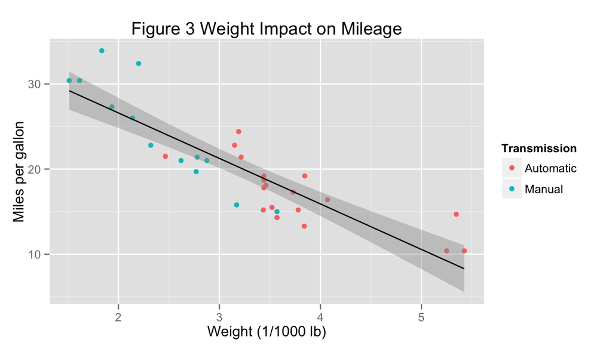